# Stepping Stones Final Report

Team 4: Charlie Bruce, Jayla Hart, Somin Lee

March 2, 2023

## Introduction

Stepping Stones was created to chart the health of children and their families in the City of Charlottesville and Albemarle County. Stepping Stones includes data on 38 indicators chosen to measure child and family well-being. Stepping Stones is intended to provide accurate data, stimulate community dialogue and action regarding regional trends in the Charlottesville/Albemarle community.

## Team 4 Variables

We are analyzing the following data for the Stepping Stones progress report:

**Variable 1:** High school graduation rates (%)

**Variable 2:** Children living with two parents (%)

**Variable 3:** School suspensions (#/1000 students)

**Variable 4:** Children in need of supervision (#/1000 youth 10-17)

**Variable 5:** Prenatal care in first trimester (% of live births)

**Variable 6** Juvenile Arrest Rates (per 1000 people)

Each of these measures, illustrated in the graphs below, capture a different dimension of community well-being and health across the Charlottesville-Albemarle region.

## Education

### Graduation Rates

#### Trend

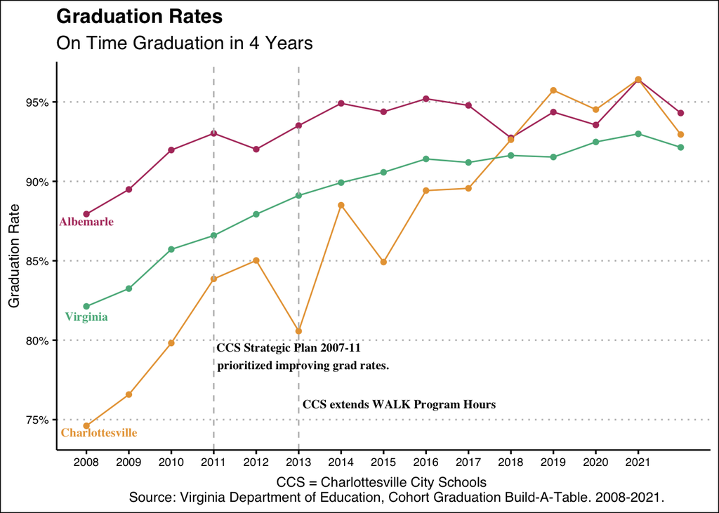

#### About

On-time graduation is graduation within four years of entering high school.

A high school diploma is a standard requirement for most jobs - and for higher education opportunities. Not completing high school is linked to a variety of factors that can negatively impact health, including limited employment prospects, low wages, and even poverty. Therefore, on-time graduation is an important indicator of whether localities are preparing substantial amounts of college/career-ready students. Since 2008, a greater share of high school students are graduating. Statewide, rates have increased 10 percent between 2008 and 2021. Albemarle has steadily improved its rates while Charlottesville experienced slight dips before gradually increasing since 2015.

Notably, [improving graduation rates](https://www.cityofpromise.org/history) was a priority outlined in Charlottesville City Schools (CCS) Strategic Plan for 2007-2011. Additionally, after a drop in graduation in 2013, CCS extended the hours of its [WALK Program](http://charlottesvilleschools.org/home/programs-activities/walk-program-at-charlottesville-high-school/) - an opportunity for students at risk of dropping out or failing to earn credits needed for graduation. The program is predominantly funded through Title I dollars and donations. After the hours extension, 2013-14 enrollment in the program increased - as did graduation rates that year.

As noted by then- Assistant Superintendent, [Gertrude Ivory,](https://www.cvilletomorrow.org/walk-program-extended-hours/) there are several underlying issues linked to lower graduation rates. Students may have difficulties attending schools due to trauma, job responsibilities, lack of daycare, or adjustment struggles. With these struggles in mind, CCS created flexible learning support for its students and committed to more rigorous academic expectations.

## Family Characteristics

### Children in Two-Parent Households

#### Trend

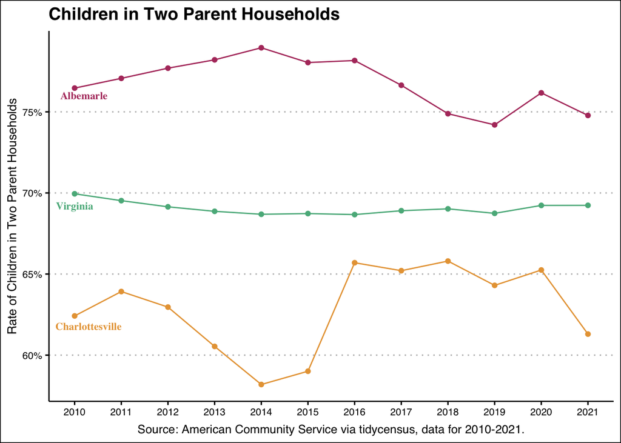

#### About

Research suggests children living in two-parent households, on average, are more advantaged than single-parent households. Examining trends is important since family structure can influence children’s socioemotional development and [academic achievement](https://onlinelibrary.wiley.com/doi/full/10.1111/j.1741-3737.2011.00825.x).

According to the [Census Bureau](https://www.census.gov/library/stories/2021/04/number-of-children-living-only-with-their-mothers-has-doubled-in-past-50-years.html), the percentage of children with two parents dropped from 85 percent in 1968 to 70 percent in 2020. In this same period, the number of children living only with their mothers nearly doubled from 11 percent to 21 percent.

Stepping Stones does not share whether children living in single-parent households reside with their mother or father. Understanding these differences could bring tremendous insight particularly in Charlottesville, where almost a third of children lived in single-parent households in 2016. Lower rates of two-parent households can be indicators of higher rates of divorce/separation (leading to split custody) or changing incarceration trends (leading to children with one un-incarcerated parent).

## Discipline in Schools

### School Suspensions

#### Trend

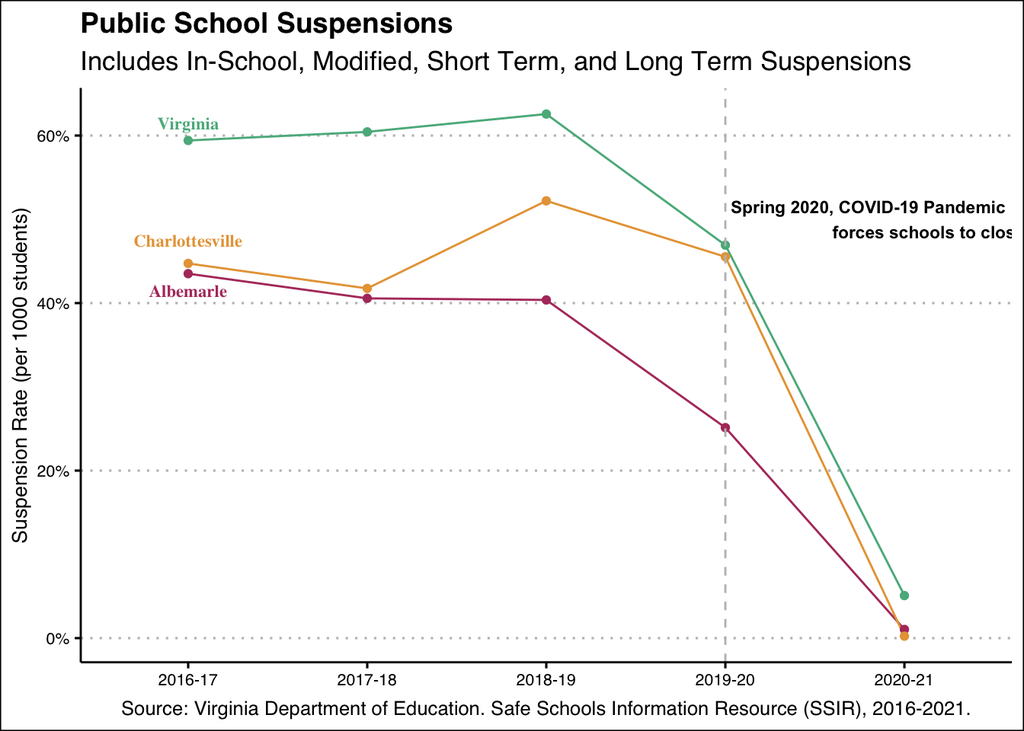

#### Trend (with prior data)

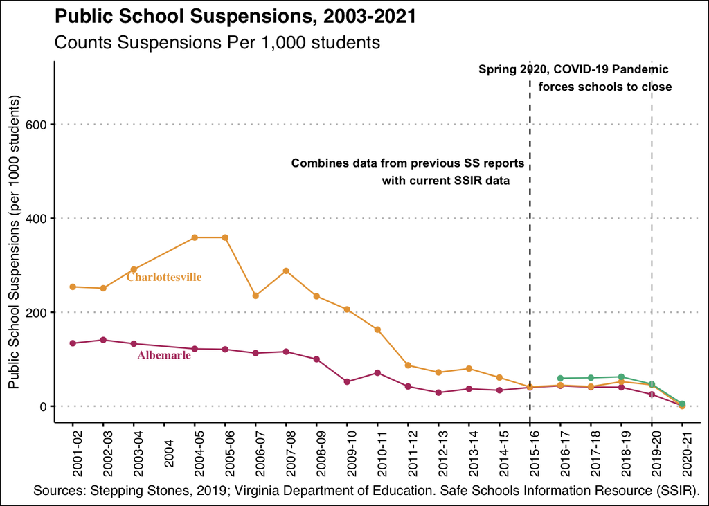

#### About

School discipline is the temporary removal of a student from their school -the regular educational setting - for a violation of school policies or rules. During suspension, a student is not allowed to attend school or school activities for a set length of time. This graphic summarizes numerous types of school suspensions (such as in-school versus short/long term), although variation within type does exist.

Typically, Charlottesville suspends students at a higher rate than Albemarle. Nevertheless, both localities have had decreased suspension rates since the school year 2018-19. The on-set of the COVID pandemic and move to virtual instruction can partially explain some of the reduction. With truancy changing substantially during the period when school is online and the declining opportunities for other behaviors that might be harmful as student had fewer ways to socialize together.

In 2020, Albemarle County Public Schools introduced the [STEP program](https://www.nbc29.com/2020/02/07/albemarle-county-public-schools-program-provides-alternative-out-of-school-suspension/), which likely contributed to the decline in suspensions. STEP is a preferable alternative to out-of-school suspension. Students work on schoolwork, meet with a counselor, discuss the incident and find strategies to avoid future incidents- dealing with the underlying issues that led to conflicts.

Statewide, suspensions are used an exclusionary disciplinary tool. In 2016, the [Legal Aid Justice Center](https://www.justice4all.org/wp-content/uploads/2016/04/Suspended-Progress-2017.pdf) found Virginia schools use exclusionary discipline with young students at high rates. The state issued over 17,300 short-term suspensions and at least 93 long-term suspensions to children in pre-K through third grade alone. Virginia also disproportionately suspends Black students and students with disabilities. Excessive suspensions, often for minor offenses, contribute the school-to-prison pipeline and prevent students from learning. School leaders should be mindful of the long-term consequences of suspensions on students and continue seeking alternative, restorative practices to discipline students.

*Statistical Note:* Our original data contained several “<” instead of a number of suspended students. The “<” symbol represents a nonzero number of students that fall below the state-mandated “Suppression rule” threshold of 9. This threshold is meant to protect students’ identities. [More information can be read through VDOE.](https://virginiaisforlearners.virginia.gov/statistics_reports/research_data/index.shtml)

## Conduct in Community

### Children in Need of Supervision

#### Trend

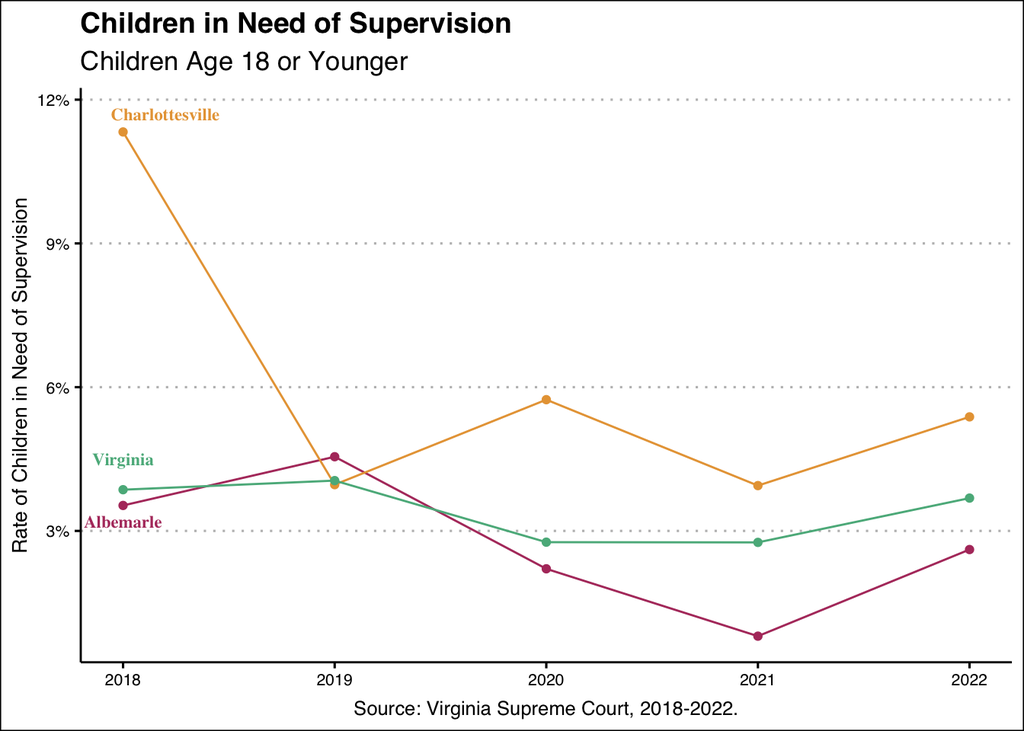

#### About

[According to the Virginia Code](https://www.vacourts.gov/courts/jdr/Lynchburg/supervision.html) defines “a child in need of supervision” as a student who is habitually absent from school despite the system’s reasonable effort to maintain their regular attendance. This rule is part of a larger set of rules around familial relationships, particularly the parents responsibility of their children’s conduct.

The number of children in need of supervision is used to understand household relationships and educational environments. A growing rate of chronically truant children or runaways may indicate a need for greater student support services or unsupportive homes.

Since 2019, Charlottesville’s rates of children in need of supervision have fallen closer to the state and Albemarle’s rates. Albemarle remains below state rates however, there is a recent up-tick as of 2022. The county offers [Family Support Programs](https://www.albemarle.org/government/social-services/children-s-services/family-support) like meeting basic needs of life (food, financial, housing) emotional needs, and other methods to help students achieve their greatest potential.

The increase and decrease in CHINS does not correspond with the COVID pandemic, which indicates school support staff were able to stay connected to students during the pandemic.

### Juvenile Arrests

#### Trend

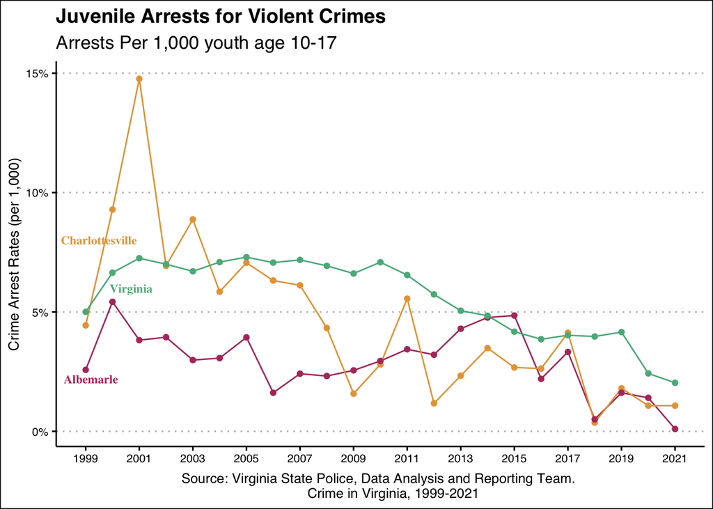

#### About

This measure captures juvenile (youth younger than 18) arrests for crimes against persons. According to the [US Department of Justice](https://ojjdp.ojp.gov/publications/juvenile-arrests-2019.pdf) violent crimes as murder, aggravated assault, sexual assault, and robbery.

Although there are spikes in juvenile arrests, Charlottesville’s rates have gradually gone down after an initial dramatic drop in 2002. After a decade of arrest increases (up to 5 percent), Albemarle’s rates have dropped since 2017. Charlottesville and Albemarle arrest rates remain below Virginia average.

Once a juvenile enters the system, they are either issued a court summons (for minor offenses) or go through a formal intake process. Juveniles may be referred to crisis shelters, educational programming with their parents, or detained for up to 72 hours before going to a hearing for further actions.

*Statistical Note:* This measure does not disaggregate by type of crime due to data limitations.

## Infant Health

### Pre-Natal Care

#### Trend

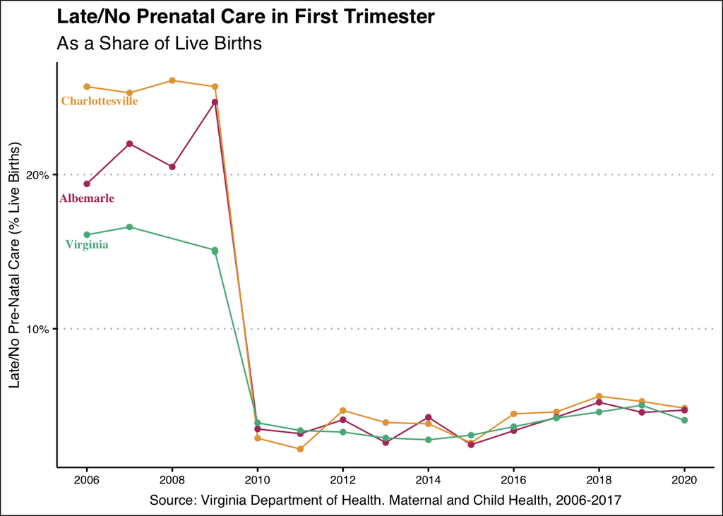

#### About

Prenatal care typically includes physical exams, weight checks, urine and/or blood samples, ultrasounds, and discussions about the mother’s and fetus’s health. Access to adequate prenatal care is important to reduce the risk of pregnancy complications.